# Notebook 7.4 - Image Segmentation using Computer Vision

In this notebook we provide an example of Image Segmentation in practice, using the OpenCV, Keras and TensorFlow libraries. If you run the notebook, you will see a video recorded from the windscreen of a window, superimposed with a segmentation layer, that highlights the current lane.

This is what the output that you should see:

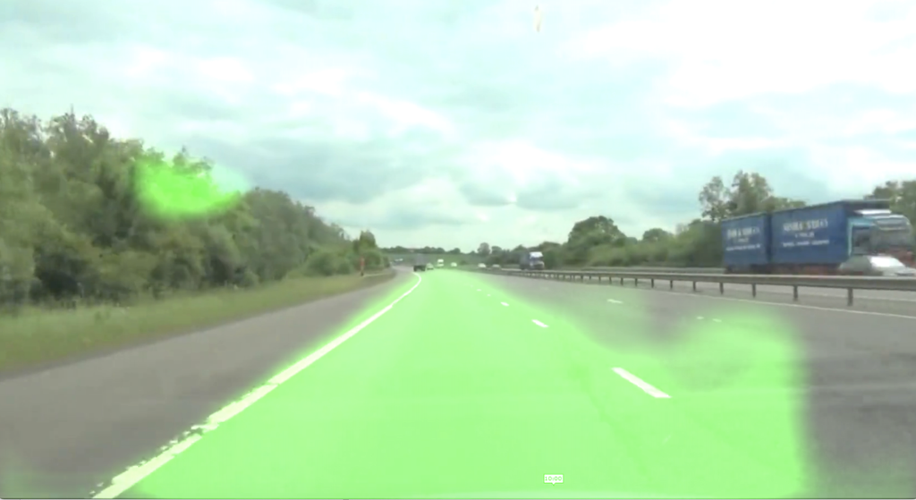

This particular demonstration requires an advanced set of libraries, that can be quite tricky to install. We tested this notbook in both Windows and MacOS, and it should function correctly.

We need a particular version of the opencv library for it to work correctly in both platforms, and therefore we will ensure that some other versions that you might have installed are not present (using the pip uninstall command).

```python
!pip uninstall opencv-python opencv-contrib-python -y
!pip install scipy keras tensorflow opencv-python-headless h5py==2.10.0
%matplotlib auto
```

```
WARNING: Skipping opencv-python as it is not installed.
WARNING: Skipping opencv-contrib-python as it is not installed.
Using matplotlib backend: MacOSX
```

```python
import os
import cv2
import numpy as np
from keras.models import model_from_json
```

For the purposes of this notebook, we will use a pre-trained model, that will be able to identify the segment of the road that belongs to the current lane.

The following function will resize the frames of the video to a size that is compatible with our model.

```python
def prepare_image(image):
    resized_image = cv2.resize(image, (160, 80))
    img = np.array(resized_image)[None, :, :, :]
    return img
```

The following function will pretinct the presense of a lane segment on a perticular frame

```python
def lane_prediction(img):
    global lane_fits

    # Predict lane positions with the pre-trained neural network
    prediction = model.predict(img)[0] * 255
    lane_fits.append(prediction)

    # Keep track of last five preditions to average
    if len(lane_fits) > 5:
        lane_fits = lane_fits[1:]
    averge_fit = np.mean(np.array([i for i in lane_fits]), axis = 0)

    # Denote lane in green color
    blanks = np.zeros_like(averge_fit).astype(np.uint8)
    lane_drawn = np.dstack((blanks, averge_fit, blanks))

    # Resize the lane drawing to match original image
    lane_image = cv2.resize(lane_drawn, (1280, 720))
    lane_image_norm = cv2.normalize(lane_image, None, 0, 255, cv2.NORM_MINMAX, cv2.CV_8U)

    return lane_image_norm
```

Load video file and pre-trained model

```python
# path to video file
video_file = 'data/example.mp4'
# load video file
cap = cv2.VideoCapture(video_file)
# store lane prediction results
lane_fits = []

# load the pre-trained model
json_file = open('model/model.json', 'r')
json_model = json_file.read()
json_file.close()
model = model_from_json(json_model)

# load the wieghts of the model
model.load_weights('model/model.h5')
```

Read the video frames in a loop and send to model for lane detection  
Press "Q" to exit the streaming

```python
while(cap.isOpened()):
    success, frame = cap.read()
    if not success:
        break
    original_image = cv2.resize(frame, (1280, 720))
    img = prepare_image(frame)
    lanes = lane_prediction(img)
    # merge detection results to original image
    merged_image = cv2.addWeighted(original_image, 1, lanes, 1, 0)
    cv2.imshow('Lane detection', merged_image)
    if cv2.waitKey(10) & 0xFF == ord('q'):
        break

cap.release()
cv2.destroyAllWindows()
cv2.waitKey(1)
```

```
-1
```